# Introduction to Python

## About Python

- Guido van Rossum, first release in 1991
- Code readability
- Spaces are used to delimit code blocks instead of special characters, and indents are very important
- The Python syntax allows you to use the program paradigm you prefer—procedural, object-oriented, or functional programming
- Version 2.x and 3.x, version 2.x will “retire” on 1.1.2020 : [clock](https://pythonclock.org/)

## Running Python code

- Text editors:
  - General editors for any text file
  - Most are not design with only Python in mind
  - Most popular: Sublime Text and Atom
- Full IDEs:
  - Design specifically for Python
  - Lots of extra functionality
  - Most popular: Spyder and PyCharm
- Notebook environments:
  - Great for learning
  - See input and output next to each other

## Installing Python

- just Python installation: [Python](https://www.python.org/downloads/)
- Python+IDE installation go to:Anaconda
- also Miniconda

## Resources

- Python books (https://pythonbooks.org/)
- Python books (https://pythonbooks.revolunet.com/)
- Python newsletters (https://www.pythonweekly.com/)
- Python for beginners (https://www.pythonforbeginners.com/)

## Libraries

- [Cheese Shop: pypi.org](https://pypi.org/): official repository; default repository for pip
- [Python wiki](https://wiki.python.org/moin/FrontPage)
- [Useful libraries](https://wiki.python.org/moin/UsefulModules)

## pip and conda (1)

- Pip is the Python Packaging Authority’s recommended tool for installing packages from the Python Package Index
- Conda is a cross platform package and environment manager that installs and manages conda packages from the Anaconda repository
- A major reason for combining pip with conda is when one or more packages are only available to install via pip

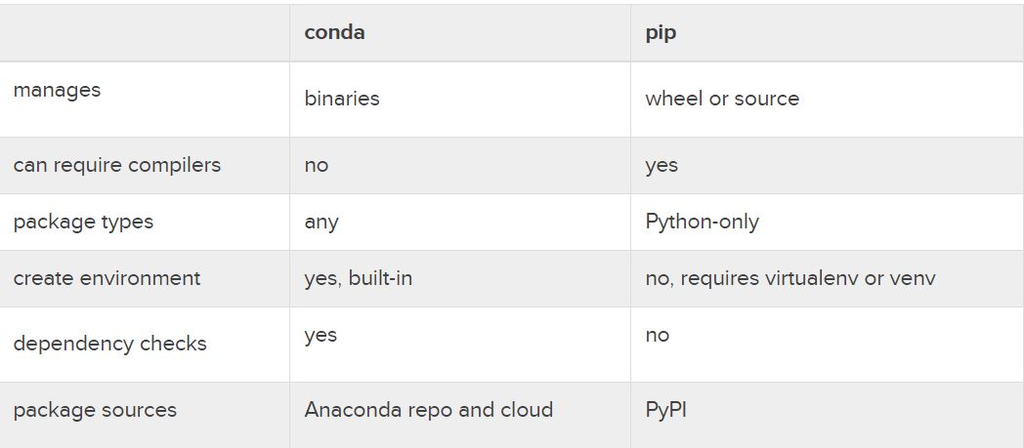

## pip and conda (2)

- most of data science packages are stored in Anaconda repository
- majority of packages is stored in pypi.org repository
- combining conda and pip
- conda comes with anaconda distribution
- installing pip: conda install -c anaconda pip

## Anaconda

[figure not shown]

## How to see which modules are installed

- pip list
- pip list –outdated
- check your installed modules
- are there many outdated modules?

## Installing , upgrading and downgrading module

- conda/pip install module_name
- conda/pip install -U module_name
- pip freeze | findstr module_name
- pip install module_name==version (could be older than current)

## Where modules are installed

- use inspect module:
  - import inspect
  - inspect.getfile(module_name)

## Virtual environment

- for the development
- backward compatibility
- virtualenv module
- pip install virtualenv
- go to your project folder and run:
  - virtualenv –python C:\Path\To\Python\python.exe name_of_virtual_env
  - .\name_of_virtual_env\Scripts\activate
- deactivate
- to remove the environment, just delete the folder

## Lab

- open conda prompt
- on c disk create folder dummyProject (use md dummyProject)
- go to dummyProject (use cd dummyProject)
- create virtual environment called firstVirtualEnv:
  - virtualenv –python python.exe firstVirtualEnv
- activate it
- check installed modules
- install pandas version 0.23.2
- upgrade it to version 0.25.1
- downgrade it to 0.24.1
- deactivate it

## What shall we use

- Jupyter notebook/lab
- Spyder

## Changing default folder for Jupyter notebook

- go to cmd (or Anaconda Prompt) and run: “jupyter notebook –generate-config”
- C:/Users/username/.jupyter/jupyter_notebook_config.py
- open jupyter_notebook_config.py with text editor and search for #c.NotebookApp.notebook_dir = ’’
- replace to c.NotebookApp.notebook_dir = ‘/the/path/to/home/folder/’

## Jupyter notebook extensions

- nbextensions: conda install -c conda-forge jupyter_contrib_nbextensions
- nbextensions manager: conda install -c conda-forge jupyter_contrib_nbextensions
- enable Code prettify, Table of contents, Hinterland